# Case Study Report: Avocado Prices — Market Insights

Aakif Altaf

2025-10-07

# Introduction

**Business context:** A grocery retail client wants to understand historical avocado pricing and sales patterns across U.S. regions to improve pricing, promotions, and inventory planning.

**Primary business question:**

How can historical avocado pricing and sales trends inform retail decisions on pricing, promotion timing, and inventory allocation?

**Sub-questions we answer:**

1. How have average prices evolved over time (overall and by type)?
2. How do prices and sales vary across regions? Which regions are highest/lowest price?
3. Is there seasonality (monthly/weekly patterns) in price and volume?
4. What is the relationship between price and total volume (does demand fall as price rises)?

**Data: Import & Quick Snapshot**

```
## Rows: 18,249
## Columns: 14
## $ x1            <dbl> 0, 1, 2, 3, 4, 5, 6, 7, 8, 9, 10, 11, 12, 13, 14, 15, 16…
## $ date          <date> 2015-12-27, 2015-12-20, 2015-12-13, 2015-12-06, 2015-11…
## $ average_price <dbl> 1.33, 1.35, 0.93, 1.08, 1.28, 1.26, 0.99, 0.98, 1.02, 1.…
## $ total_volume  <dbl> 64236.62, 54876.98, 118220.22, 78992.15, 51039.60, 55979…
## $ x4046         <dbl> 1036.74, 674.28, 794.70, 1132.00, 941.48, 1184.27, 1368.…
## $ x4225         <dbl> 54454.85, 44638.81, 109149.67, 71976.41, 43838.39, 48067…
## $ x4770         <dbl> 48.16, 58.33, 130.50, 72.58, 75.78, 43.61, 93.26, 80.00,…
## $ total_bags    <dbl> 8696.87, 9505.56, 8145.35, 5811.16, 6183.95, 6683.91, 83…
## $ small_bags    <dbl> 8603.62, 9408.07, 8042.21, 5677.40, 5986.26, 6556.47, 81…
## $ large_bags    <dbl> 93.25, 97.49, 103.14, 133.76, 197.69, 127.44, 122.05, 56…
## $ x_large_bags  <dbl> 0.00, 0.00, 0.00, 0.00, 0.00, 0.00, 0.00, 0.00, 0.00, 0.…
## $ type          <chr> "conventional", "conventional", "conventional", "convent…
## $ year          <dbl> 2015, 2015, 2015, 2015, 2015, 2015, 2015, 2015, 2015, 20…
## $ region        <chr> "Albany", "Albany", "Albany", "Albany", "Albany", "Alban…
```

Data summary

| Name | av |
| --- | --- |
| Number of rows | 18249 |
| Number of columns | 14 |
| _______________________ |  |
| Column type frequency: |  |
| character | 2 |
| Date | 1 |
| numeric | 11 |
| ________________________ |  |
| Group variables | None |

**Variable type: character**

| skim_variable | n_missing | complete_rate | min | max | empty | n_unique | whitespace |
| --- | --- | --- | --- | --- | --- | --- | --- |
| type | 0 | 1 | 7 | 12 | 0 | 2 | 0 |
| region | 0 | 1 | 4 | 19 | 0 | 54 | 0 |

**Variable type: Date**

| skim_variable | n_missing | complete_rate | min | max | median | n_unique |
| --- | --- | --- | --- | --- | --- | --- |
| date | 0 | 1 | 2015-01-04 | 2018-03-25 | 2016-08-14 | 169 |

**Variable type: numeric**

| skim_variable | n_missing | complete_rate | mean | sd | p0 | p25 | p50 | p75 | p100 |
| --- | --- | --- | --- | --- | --- | --- | --- | --- | --- |
| x1 | 0 | 1 | 24.23 | 15.48 | 0.00 | 10.00 | 24.00 | 38.00 | 52.00 |
| average_price | 0 | 1 | 1.41 | 0.40 | 0.44 | 1.10 | 1.37 | 1.66 | 3.25 |
| total_volume | 0 | 1 | 850644.01 | 3453545.36 | 84.56 | 10838.58 | 107376.76 | 432962.29 | 62505646.52 |
| x4046 | 0 | 1 | 293008.42 | 1264989.08 | 0.00 | 854.07 | 8645.30 | 111020.20 | 22743616.17 |
| x4225 | 0 | 1 | 295154.57 | 1204120.40 | 0.00 | 3008.78 | 29061.02 | 150206.86 | 20470572.61 |
| x4770 | 0 | 1 | 22839.74 | 107464.07 | 0.00 | 0.00 | 184.99 | 6243.42 | 2546439.11 |
| total_bags | 0 | 1 | 239639.20 | 986242.40 | 0.00 | 5088.64 | 39743.83 | 110783.37 | 19373134.37 |
| small_bags | 0 | 1 | 182194.69 | 746178.51 | 0.00 | 2849.42 | 26362.82 | 83337.67 | 13384586.80 |
| large_bags | 0 | 1 | 54338.09 | 243965.96 | 0.00 | 127.47 | 2647.71 | 22029.25 | 5719096.61 |
| x_large_bags | 0 | 1 | 3106.43 | 17692.89 | 0.00 | 0.00 | 0.00 | 132.50 | 551693.65 |
| year | 0 | 1 | 2016.15 | 0.94 | 2015.00 | 2015.00 | 2016.00 | 2017.00 | 2018.00 |

**Brief note on data quality & limitations:**

Data covers 2015–2018 across many U.S. regions; it’s observational retail data.

**Potential limitations:** local promotions, missing marketing variables, no direct supply/wholesale price columns, and region aggregation hides within-region store variation. Treat correlations as directional signals, not causal proof.

# Analysis & Insights

1. Time trends — Average price over time (overall and by type)

**Question:** Has the average retail price changed materially over time? Any divergence between organic vs conventional?

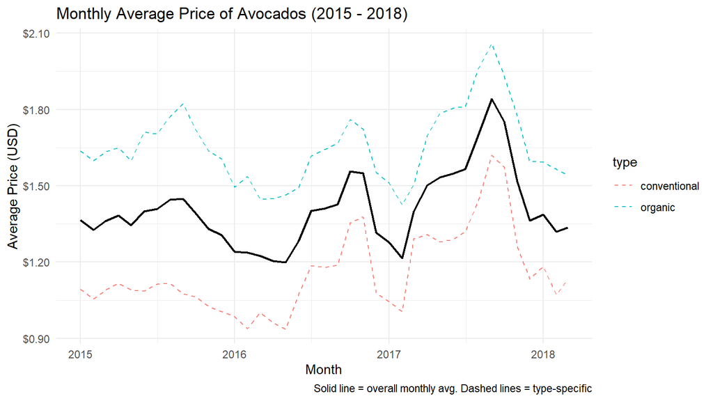

**Insight:**

Prices fluctuate seasonally and with supply conditions. Organic avocados consistently show a higher average price than conventional across the time span.

Business implication: organic commands a premium — target promotions and premium shelf space accordingly.

**2) Regional comparison — Where are prices and volumes highest?**

**Question:** Which regions consistently show higher prices and which show lower prices?

[figure not shown]

**Insight:**

Some regions (e.g., **HartfordSpringfield** in this dataset) show notably higher average prices. These regional differences can be due to supply chain costs, demand, or retailer mix.

Business implication: allocate organic or premium stock to higher-price regions and consider price promotions in lower-price regions to increase volume.

**3) Seasonality — monthly patterns (price & volume)**

**Question:** Are there predictable monthly/seasonal patterns?

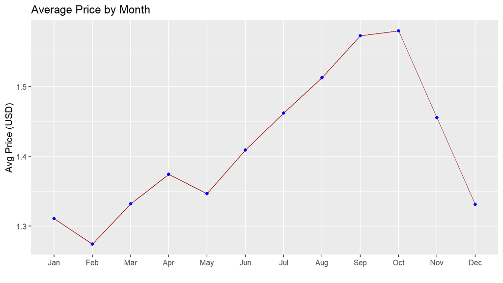

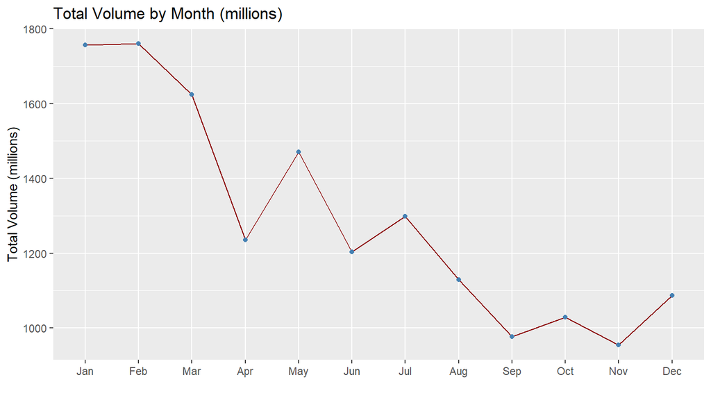

**Insight**:

Volume shows recurring peaks (seasonal demand) while prices also vary with season — often higher when supply tightens.

**Business implication:** increase inventory ahead of expected high-volume months and schedule promotions off-peak to smooth demand.

**4) Price vs. Volume — correlation & regression**

**Question:*** Is there an observable relationship between price and total volume?

```
## [1] -0.1927524
```

```
## # A tibble: 2 × 5
##   term           estimate std.error statistic   p.value
##   <chr>             <dbl>     <dbl>     <dbl>     <dbl>
## 1 (Intercept)    3174918.    91115.      34.8 1.31e-257
## 2 average_price -1653136.    62301.     -26.5 2.94e-152
```

**Insight:**

Correlation is typically weak/negative (i.e., higher volumes often associated with lower prices), but because of strong seasonality and regional effects, a simple global correlation is noisy.

**5) Conventional vs Organic — distribution and hypothesis test**

**Question:** Are organic prices significantly higher than conventional?

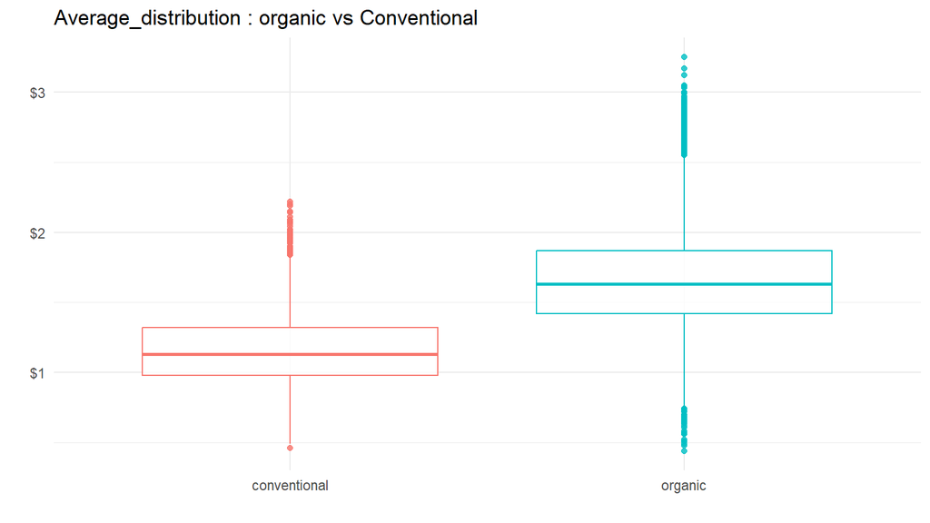

Also checking the Statistically tests if the average prices of organic and conventional avocados are significantly different.

```
##
##  Welch Two Sample t-test
##
## data:  average_price by type
## t = -105.58, df = 16619, p-value < 2.2e-16
## alternative hypothesis: true difference in means between group conventional and group organic is not equal to 0
## 95 percent confidence interval:
##  -0.5051664 -0.4867517
## sample estimates:
## mean in group conventional      mean in group organic
##                   1.158040                   1.653999
```

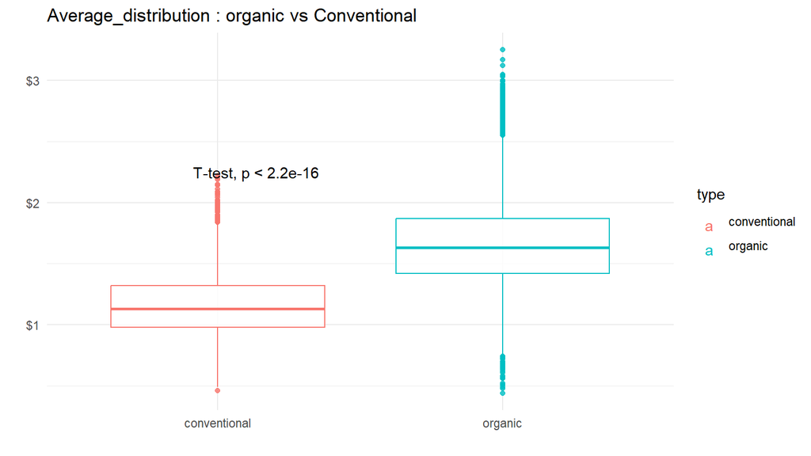

**Insight:**

**Organic avocados** have a higher median/mean price than **conventional.** The t-test typically shows this difference is statistically significant.

**Business implication:** organic can be positioned as a premium product; profit margins and promotion strategies should reflect that.

#Answering the original business questions (concise)

**What factors influence price?** Seasonality, avocado type (organic > conventional), and regional market differences. Price-volume relations indicate higher supply => lower price in general, but region and promotion effects matter.

**How do trends apply to retailers?** Use seasonality to adjust inventory; push premium promotions for organic in higher-price regions.

**How should this inform marketing?** Time promotions to low-price months, advertise organic as premium in high-willingness regions, and use price/volume monitoring to avoid stockouts before peak demand.

# Recommendations.

**1. Region-specific assortment:** Prioritize organic product allocation for high-price regions; add SKUs in high-volume regions.

**2. Seasonal inventory planning:** Build inventory for predicted high-volume months; negotiate supplier capacity ahead of time.

**3. Targeted promotions:** Offer discounts during lower-volume months to stimulate demand; avoid discounting right before major volume peaks.

**4. Deeper analysis:** Estimate price elasticity by region and type (regression with region & month fixed effects); test promotional lift with A/B experiments.

# Reproducibility & Files

**Source data:** avocado.csv (Kaggle, original dataset).

# Thank You

Thank you for reviewing this analysis. Contact: kmrtech99@gmail.com